# Deliverables123

install packages for analysis

```r
installed.packages("rio")
installed.packages("ggplot2")
installed.packages("DescTools")
install.packages("dplyr")
```

```r
install_formats()
rm(list = ls())

library(rio)
library(ggplot2)
library(DescTools)
library(dplyr)
```

Getting the data TABLE from the file

```r
link='https://github.com/superadlerrrk/543/blob/main/Deliverable1/Crime_Data.csv?raw=true'
crime = import(link)
```

This is the list of the variables (columns) from the data loaded …and the first thirty values:

```r
names(crime)
head(crime$"Primary Offense Description",30)
```

[output not shown]

Checking which columns contain null values

```r
cols_with_nulls <- colSums(is.na(crime))
```

Printing the column names with null values

```r
sum(is.na(crime$"Reported Time"))
```

```
[1] 0
```

Creating a logical vector indicating which rows have complete data in my_column

```r
complete_rows <- complete.cases(crime$"Reported Time")
complete_rows <- complete.cases(crime$"Occurred Time")
```

Get absolute values by each Precinct

```r
absoluteT=table(crime$Precinct)
absoluteT
```

```
     EAST     NORTH     SOUTH SOUTHWEST   UNKNOWN      WEST
    74010    160305     71206     47019      3166    143988
```

Transform the absolute count into percent or relative frequencies:

```r
prop.table(absoluteT)
```

```
       EAST       NORTH       SOUTH   SOUTHWEST     UNKNOWN        WEST
0.148110644 0.320806333 0.142499210 0.094095586 0.006335878 0.288152349
```

Transform the range of the proportions into percents:

```r
propT=prop.table(absoluteT)*100
propT
```

```
      EAST      NORTH      SOUTH  SOUTHWEST    UNKNOWN       WEST
14.8110644 32.0806333 14.2499210  9.4095586  0.6335878 28.8152349
```

Get the pie plots by Precinct:

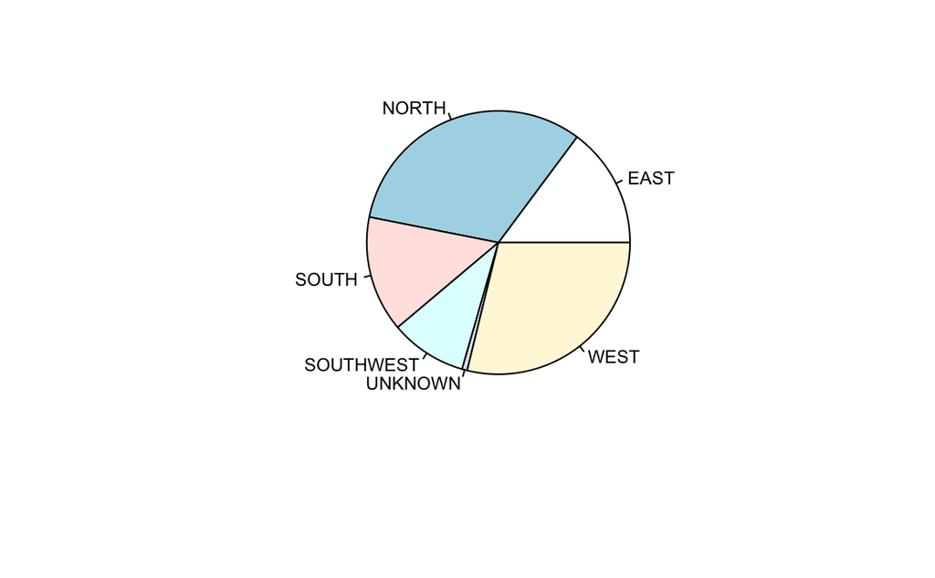

```r
pie(absoluteT, cex = 0.7)
```

Subset the data frame to remove rows with null values in my_column

```r
crime <- crime[complete_rows, ]

sum(is.na(crime$"Reported Time"))
sum(is.na(crime$"Occurred Time"))

crime <- crime %>%
  mutate(Precinct = if_else(Precinct == "", "UNKNOWN", Precinct))

crime_grouped <- crime %>%
  group_by(Precinct, Neighborhood) %>%
  summarise(n = n())

crime_totals <- crime_grouped %>%
  group_by(Precinct) %>%
  summarise(total_entries = sum(n))

crime_grouped <- crime_grouped %>%
  left_join(crime_totals, by = "Precinct") %>%
  mutate(ratio = n / total_entries)

precincts <- unique(crime_grouped$Precinct)

for (precinct in precincts) {
  data <- filter(crime_grouped, Precinct == precinct)
  plot_title <- paste0(precinct, "Crime Entries by Neighborhood")

  pie_chart <- ggplot(data, aes(x="", y=ratio, fill=Neighborhood)) +
    geom_bar(stat="identity", width=1) +
    coord_polar("y", start=0) +
    labs(title=plot_title) +
    theme_void()

  print(pie_chart)
}

crime$grouped_time <- cut(crime$"Occurred Time",
      breaks = c(0, 1, 559, 1159, 1759, 2359),
      labels = c("Unknown", "Midnight", "Morning", "Afternoon", "Evening"),
      include.lowest = TRUE)

table(crime$Precinct, crime$grouped_time)

Get the counts of each group in grouped_time
```

[output not shown]

```r
time_counts <- table(crime$grouped_time)
```

Plot a bar plot

```r
barplot(time_counts,
        main = "Occurrences by Time of Day",
        xlab = "Time of Day",
        ylab = "Count")

ggplot(crime, aes(x = grouped_time, fill = Precinct)) +
  geom_bar() +
  labs(x = "Grouped Occurred Time", y = "Count of Entries")

crime$offense_category <- gsub("-.*", "", crime$`Primary Offense Description`)

off_ctgr <- unique(crime$`offense_category`)
```

[output not shown]

Create a data frame with the count of entries by offense category

```r
offense_counts <- data.frame(table(crime$offense_category))
```

Sort the offense categories by count of entries in descending order

```r
sorted_offenses <- offense_counts[order(offense_counts$Freq, decreasing = TRUE), ]
```

Select the top 10 offense categories by count of entries

```r
top_10_offenses <- head(sorted_offenses, 10)
```

Create a bar plot of the top 10 offense categories

```r
ggplot(top_10_offenses, aes(x = reorder(Var1, Freq), y = Freq, fill = Var1)) +
  geom_col() +
  xlab("Offense Category") +
  ylab("Count of Entries") +
  ggtitle("Top 10 Offense Categories by Count of Entries") +
  theme(axis.text.x = element_text(angle = 45, hjust = 1))
```

[output not shown]

Group and summarize the data

```r
crime_counts <- crime %>%
  group_by(offense_category, Neighborhood) %>%
  summarize(count = n()) %>%
  ungroup()
```

Create the plot

```r
ggplot(crime_counts, aes(x = offense_category, y = Neighborhood, fill = count)) +
  geom_tile() +
  theme(axis.text.x = element_text(angle = 90, hjust = 1,size = 4),
        axis.text.y = element_text(size = 4)) +
  scale_fill_gradient(low = "white", high = "steelblue") +
  labs(title = "Count of entries by offense category and Neighborhood",
       x = "Offense category",
       y = "Neighborhood")
```

[output not shown]

Group and summarize the data

```r
crime_counts <- crime %>%
  group_by(grouped_time, offense_category) %>%
  summarize(count = n()) %>%
  ungroup()
```

Create the plot

```r
ggplot(crime_counts, aes(x = grouped_time, y = offense_category, fill = count)) +
  geom_tile() +
  theme(axis.text.x = element_text(angle = 90, hjust = 1,size = 4),
        axis.text.y = element_text(size = 4)) +
  scale_fill_gradient(low = "white", high = "steelblue") +
  labs(title = "Count of entries by offense category and grouped_time",
       x = "Grouped_time",
       y = "Offense category")
```

[output not shown]